# Medidas de centralización y dispersión

## Puntuales

### Estadísticos de centralización

#### Estadísticos básicos Media, mediana, cuartiles, percentiles y la moda

```r
estadisticos <- function(x) {

  source("moda.r") # Carga la función moda()

  cat("\nn=",length(x),"\nMedia=",mean(x),"\nMediana=",median(x),"\nModa=",moda(x),
        "\nVarianza=",var(x),"\nDesviación típica=",sd(x),"\n\n")

  print(quantile(x))

  per <- c(0,1/3,2/3,1) # Percentiles 0%, 33%, 66% y 100%
  print(quantile(x,p=per))

  # Diagrama de caja. Muestra la mediana y los cuartiles
  boxplot(x, main="Diagrama de caja")
}

x<- c(6,7,8,9,9,9,9,10,11,11) # Asignamos unos números al vector x

print(x) # Muestra los números ordenados de menor a mayor

estadisticos(x)
```

[output not shown]

[1] 6 7 8 9 9 9 9 10 11 11

n= 10 Media= 8.9 Mediana= 9 Moda= 9 Varianza= 2.544444 Desviación típica= 1.595131

0% 25% 50% 75% 100% 6.00 8.25 9.00 9.75 11.00

```
   0% 33.33333% 66.66667%      100%
    6         9         9        11
```

#### Resumen de los 5 numeros

El resumen de los 5 números de Tukey fue propuesto por este autor para obtener una descripción inicial de un conjunto de datos. Se suele complementar con un gráfico de cajas.

```r
# Resumen de los 5 números de Tukey aplicado a un vector

set.seed(10)
x <- rnorm(50,10,2) # 50 números aleatorios de media 10 y desviación típica 2

cinco <- fivenum(x)
seis <- summary(x)

cat("\nResumen de los 5 números:\n")
print(cinco)


boxplot(x,main="Resumen de los 5 números")


cat("\nResumen de los 5 número más la medias:\n")
print(seis)
boxplot(x,main="Resumen de los 5 números + media")
points(mean(x),pch=4,col="red")
```

[output not shown]

Resumen de los 5 números: [1] 5.629426 8.255682 9.442313 10.589090 12.203559

Resumen de los 5 número más la medias: Min. 1st Qu. Median Mean 3rd Qu. Max. 5.629 8.277 9.442 9.317 10.560 12.200

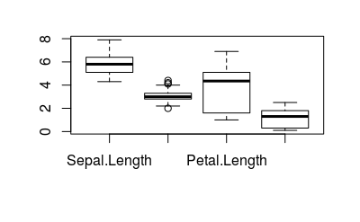

```r
# Calculo en data frames
data("iris")

# Usamos la función sapply() para aplicarlo ya que no funciona con data frames
# sapply() permite aplicar la función fivenum a cada columna automáticamente
cinco2 <- sapply(iris[-5],fivenum)
boxplot(iris[-5])
```

```r
print(cinco2)
```

```
     Sepal.Length Sepal.Width Petal.Length Petal.Width
[1,]          4.3         2.0         1.00         0.1
[2,]          5.1         2.8         1.60         0.3
[3,]          5.8         3.0         4.35         1.3
[4,]          6.4         3.3         5.10         1.8
[5,]          7.9         4.4         6.90         2.5
```

```r
# Summary puede trabajar directamente con data frames
seis2 <- summary(iris[-5])
print(seis2)
```

```
  Sepal.Length    Sepal.Width     Petal.Length    Petal.Width
 Min.   :4.300   Min.   :2.000   Min.   :1.000   Min.   :0.100
 1st Qu.:5.100   1st Qu.:2.800   1st Qu.:1.600   1st Qu.:0.300
 Median :5.800   Median :3.000   Median :4.350   Median :1.300
 Mean   :5.843   Mean   :3.057   Mean   :3.758   Mean   :1.199
 3rd Qu.:6.400   3rd Qu.:3.300   3rd Qu.:5.100   3rd Qu.:1.800
 Max.   :7.900   Max.   :4.400   Max.   :6.900   Max.   :2.500
```

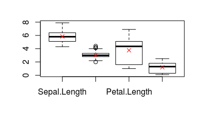

```r
medias <- sapply(iris[-5], mean) # Extraemos las medias para el gráfico
boxplot(iris[-5])
points(medias,col="red",pch=4) # Dibujamos las medias
```

## Por intervalos

Un **intervalo de confianza** es un *rango de valores*, derivado de los estadísticos de la muestra, que posiblemente incluya el valor de un parámetro de población desconocido. Debido a su naturaleza aleatoria, es poco probable que dos muestras de una población en particular produzcan intervalos de confianza idénticos. Sin embargo, si usted repitiera muchas veces su muestra, un determinado porcentaje de los intervalos de confianza resultantes incluiría el parámetro de población desconocido.

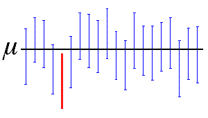

En este caso, la línea negra horizontal representa el valor fijo de la media desconocida de la población, µ. Los intervalos de confianza azules verticales que se sobreponen a la línea horizontal contienen el valor de la media de la población. **El intervalo de confianza rojo que está completamente por debajo de la línea horizontal no lo contiene. Un intervalo de confianza de 95% indica que 19 de 20 muestras (95%) de la misma población producirán intervalos de confianza que contendrán el parámetro de población.**Utilice el intervalo de confianza para evaluar la estimación del parámetro de población.

Por ejemplo, un fabricante desea saber si la longitud media de los lápices que produce es diferente de la longitud objetivo. El fabricante toma una muestra aleatoria de lápices y determina que la longitud media de la muestra es 52 milímetros y el intervalo de confianza de 95% es (50,54). Por lo tanto, usted puede estar 95% seguro de que la longitud media de todos los lápices se encuentra entre 50 y 54 milímetros.

El intervalo de confianza se determina calculando dos cosas - Una estimación de punto - Luego determinando su margen de error.

### Estimación de punto

Este valor individual estima un parámetro de población usando los datos de la muestra.

### Margen de error

Cuando usted utiliza estadísticos para estimar un valor, es importante recordar que, sin importar lo bien que esté diseñado su estudio, su estimación está sujeta a error de muestreo aleatorio. El margen de error cuantifica este error e indica la precisión de la estimación.

Usted probablemente ya entiende el margen de error, porque está relacionado con los resultados de las encuestas. Por ejemplo, una encuesta política podría indicar que el nivel de popularidad de un candidato es de 55% con un margen de error de 5%. Esto significa que el nivel de popularidad real es +/- 5% y, por lo tanto, se ubica entre 50% y 60%.

Para un intervalo de confianza bilateral, el margen de error es la distancia desde el estadístico estimado hasta cada el valor del intervalo de confianza. Cuando un intervalo de confianza es simétrico, el margen de error es la mitad del ancho del intervalo de confianza. Por ejemplo, la longitud media estimada de un árbol de levas es 600 mm y el intervalo de confianza oscila entre 599 y 601. El margen de error es 1.

Mientras mayor sea el margen de error, más ancho será el intervalo y menos seguro podrá estar usted del valor de la estimación de punto.

### Intervalo de confianza para la media

Par el cálculo del intervalo de confianza de la media usamos uno de los valores devueltos por la función t.test():

t.test(datos)$conf.int[1:2]

```r
data(iris)
 t.test(iris$Sepal.Length)$conf.int[1:2]
```

```
[1] 5.709732 5.976934
```

[1] 5.709732 5.976934

```r
t.test(iris$Sepal.Length, conf.level = 0.99)$conf.int[1:2]
```

```
[1] 5.666920 6.019747
```

[1] 5.666920 6.019747

### Intervalo de confianza para la mediana

El intervalo de confianza para la mediana se puede calcular mediante el test de Wilcoxon, wilcox.test, aunque hay que especificar que lo haga con la opción .conf.int = TRUE.

```r
wilcox.test(x, conf.int = TRUE, conf.level = 0.95)
```

[output not shown]

Podemos acceder directamente al intervalo de confianza añadiendo $conf.int

```r
wilcox.test(x, conf.int = TRUE, conf.level = 0.95)$conf.int
```

[output not shown]

### Intervalo de confianza para la varianza

R no tiene una función para calcular el intervalo de confianza de una variable por lo que proporcionamos una función que lo hace. El nivel de confianza por defecto es del 95%

Función ic.var

```r
# Intervalo de confianza para la varianza
# Modificado de http://cvb.ehu.es/open_course_ware/ca


ic.var <- function(x, conf.level=0.95) {

  alfa <- 1 - conf.level
  n <- length(x)
  l1 <- (n - 1) * var(x) / qchisq(1 - alfa / 2,n - 1)
  l2 <- (n - 1) * var(x) / qchisq(alfa / 2,n - 1)
  ic <- c(l1,l2)
  return(ic)
}
```

```r
> # Cálculo del IC de la varianza de Sepal.Length de Iris
 data(iris)

 ic.var(iris$Sepal.Length)
```

[1] 0.5531973 0.8725029

```r
 # Cálculo del IC de la varianza de todas las variables numéricas de Iris
 # usando saply
 sapply(iris[,1:4],ic.var)
```

```
 Sepal.Length Sepal.Width Petal.Length Petal.Width
```

[1,] 0.5531973 0.1532698 2.514121 0.4687388 [2,] 0.8725029 0.2417372 3.965272 0.7392948

### Intervalo de confianza para los porcentajes

Para el cálculo de los intervalos de confianza de los porcentajes usaremos binom.test en lugar de prop.test ya que esta última es una aproximación a la primera basada en la distribución normal, mientras que el primero es un test exacto. El resultado devuelto es la proporción sobre 1, si deseamos porcentajes hay que multiplicar por 100 los resultados

```r
 # Intervalo de confianza de un porcentaje o proporción

 # Se contabiliza el % de hombres y mujeres de una reunión de 60 personas
 # y se halla su intervalo de confianza
 # Hay 21 mujeres (35%) y 39 hombres (65%)

 # Mujeres
 pm <- binom.test(21,60)$conf.int[1:2]
 # pm es la proporción, se multiplica por 100 para expresar el resultado en %
 100 * pm
```

[1] 23.13264 48.40280

```r
# Hombres
 ph <- binom.test(39,60)$conf.int[1:2]
# ph es la proporción, se multiplica por 100 para expresar el resultado en %
100 * ph
```

[1] 51.59720 76.86736

El nivel de confianza del ejemplo anterior es del 95%. Para cambiarlo se usa el parámetro conf.level. Ejemplo con un nivel del 99%

```r
pm <- binom.test(21,60, conf.level = 0.99)$conf.int[1:2]
 100 * pm
```

[1] 20.05877 52.38539

```r
ph <- binom.test(39,60, conf.level = 0.99)$conf.int[1:2]
100 * ph
```

[1] 47.61461 79.94123

### Uso de un intervalo de confianza para decidir si rechazar la hipótesis nula

Supongamos que usted realiza una prueba de hipótesis. Recuerde que la decisión de rechazar la hipótesis nula (H0) o no rechazarla puede depender del valor p y del nivel de significancia elegido (también denominado α). Si el valor p es menor que o igual al nivel de significancia (α), usted rechaza H0; si es mayor que α, usted no puede rechazar H0.

La decisión también puede basarse en el intervalo de confianza (o límite) calculado usando el mismo nivel de significancia (α). Por ejemplo, la decisión para una prueba en el nivel de significancia de 0.05 puede basarse en el intervalo de confianza de 95%:

- Si el valor de referencia especificado en H0 está fuera del intervalo (es decir, es menor que el límite inferior o mayor que el límite superior), usted puede rechazar H0.
- Si el valor de referencia especificado en H0 está dentro del intervalo (es decir, no es menor que el límite inferior ni mayor que el límite superior), usted no puede rechazar H0.